# Reproducible Reserach: Peer Assessment 1

Caroline Iurillo

Friday, July 10, 2015

This is an R Markdown document for peer assessment 1 for reprodicible research.

```r
require(knitr)
```

```r
opts_chunk$set(echo = TRUE, cache = TRUE, cache.path = "cache/", fig.path = "figure/")
```

Loading and preprocessing the data

```r
activity<-read.csv(file="activity.csv",  header=TRUE,sep= ",", skipNul=TRUE)
```

packages need

```r
library(ggplot2)
```

graph of total number of steps taken per day

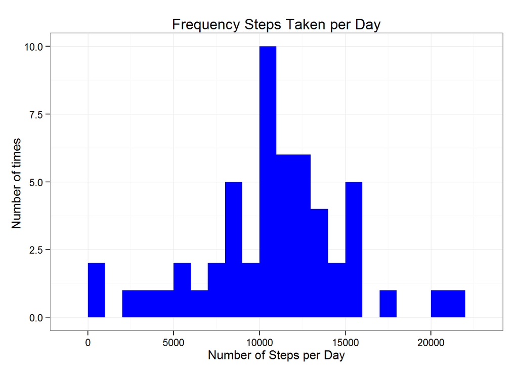

```r
ggplot(steps.day, aes(x = steps)) +
  geom_histogram(fill = "blue", binwidth = 1000) +
  labs(title="Frequency Steps Taken per Day",
       x = "Number of Steps per Day", y = "Number of times ") + theme_bw()
```

mean and median of the total number of steps taken per day mean:10766.19 median:10765

```r
mean(steps.day$steps)
```

```
## [1] 10766.19
```

```r
median(steps.day$steps)
```

```
## [1] 10765
```

average daily avtivity patttern

plot of the 5 minute intervals averaged across all days

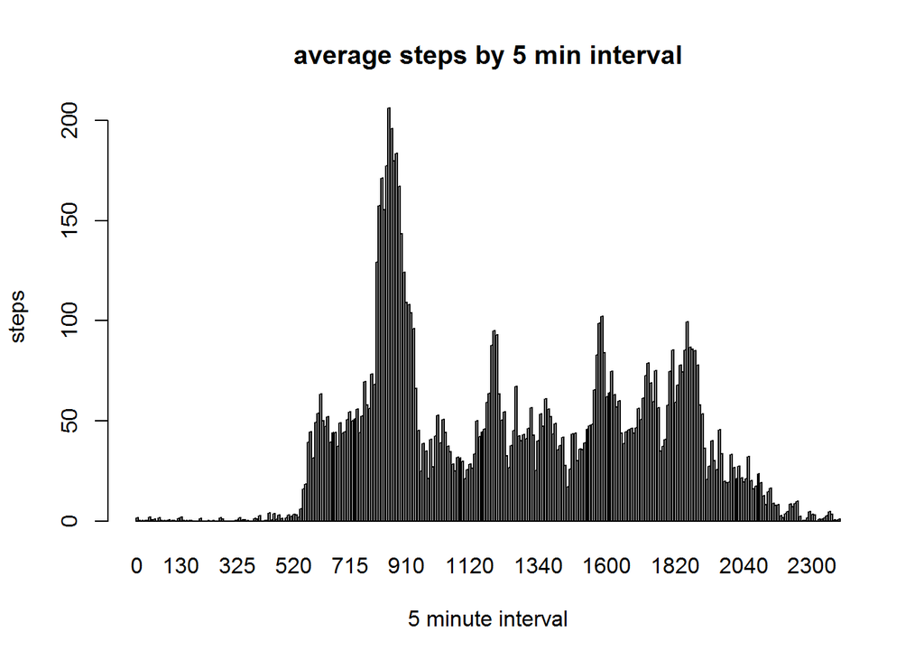

```r
steps.interval.average<-aggregate(steps ~ interval, mean, data = activity, na.rm=TRUE)

barplot(steps.interval.average$steps, names.arg = steps.interval.average$interval, main="average steps by 5 min interval",
        xlab="5 minute interval", ylab="steps")
```

5-minute interval of average across all the datas contained max number of steps 835

```r
steps.interval.average[which.max(steps.interval.average[,2]),1]
```

```
## [1] 835
```

imputing missing values current # of missing values you can see from summary: 2304

```r
summary(activity)
```

```
##      steps                date          interval
##  Min.   :  0.00   2012-10-01:  288   Min.   :   0.0
##  1st Qu.:  0.00   2012-10-02:  288   1st Qu.: 588.8
##  Median :  0.00   2012-10-03:  288   Median :1177.5
##  Mean   : 37.38   2012-10-04:  288   Mean   :1177.5
##  3rd Qu.: 12.00   2012-10-05:  288   3rd Qu.:1766.2
##  Max.   :806.00   2012-10-06:  288   Max.   :2355.0
##  NA's   :2304     (Other)   :15840
```

to fill in these missing values you can use the average interval value

```r
na_fill <- function(data, value) {
  na_index <- which(is.na(data$steps))
  na_replace <- unlist(lapply(na_index, FUN=function(idx){
    interval = data[idx,]$interval
    value[value$interval == interval,]$steps
  }))
  fill_steps <- data$steps
  fill_steps[na_index] <- na_replace
  fill_steps
}

newActivity <- data.frame(  steps = na_fill(activity, steps.interval.average),
  date = activity$date,  interval = activity$interval)


summary(newActivity)
```

```
##      steps                date          interval
##  Min.   :  0.00   2012-10-01:  288   Min.   :   0.0
##  1st Qu.:  0.00   2012-10-02:  288   1st Qu.: 588.8
##  Median :  0.00   2012-10-03:  288   Median :1177.5
##  Mean   : 37.38   2012-10-04:  288   Mean   :1177.5
##  3rd Qu.: 27.00   2012-10-05:  288   3rd Qu.:1766.2
##  Max.   :806.00   2012-10-06:  288   Max.   :2355.0
##                   (Other)   :15840
```

```r
new.steps.day<-aggregate(steps ~ date, sum, data = newActivity, na.rm=TRUE)
```

histogram of the total number of steps (with imputed values)

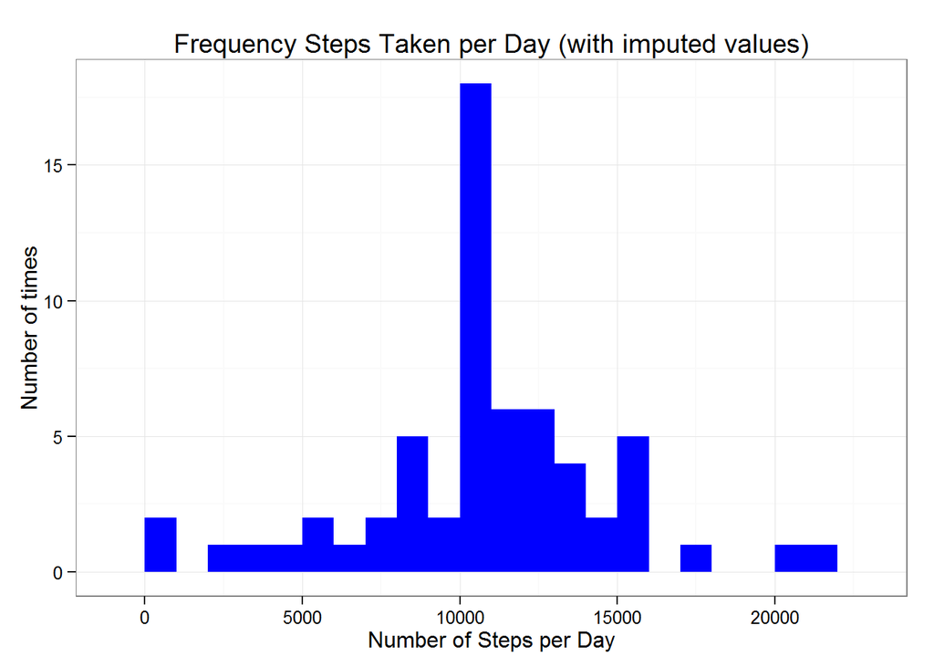

```r
ggplot(new.steps.day, aes(x = steps)) +
  geom_histogram(fill = "blue", binwidth = 1000) +
  labs(title="Frequency Steps Taken per Day (with imputed values)",
       x = "Number of Steps per Day", y = "Number of times") + theme_bw()
```

new mean and median values new mean : 10766.19 new median: 10766.19 old mean: 10766.19 old median: 10765 The mean was not changed by the imputation. However, the median was. The median steps increased when the data was imputed.

```r
mean(new.steps.day$steps)
```

```
## [1] 10766.19
```

```r
median(new.steps.day$steps)
```

```
## [1] 10766.19
```

Difference in Activity: weekday vs. weekend make new variable

```r
newActivity$interval <- as.factor(newActivity$interval)
newActivity$date <- as.Date(newActivity$date, format = "%Y-%m-%d")

weekdays_steps <- function(data) {
  weekdays_steps <- aggregate(data$steps, by=list(interval = data$interval),
                              FUN=mean, na.rm=T)
  # convert to integers for plotting
  weekdays_steps$interval <-  as.integer(levels(weekdays_steps$interval)[weekdays_steps$interval])
  colnames(weekdays_steps) <- c("interval", "steps")
  weekdays_steps
}

data_by_weekdays <- function(data) {
  data$weekday <-  as.factor(weekdays(data$date)) # weekdays
  weekend_data <- subset(data, weekday %in% c("Saturday","Sunday"))
  weekday_data <- subset(data, !weekday %in% c("Saturday","Sunday"))

  weekend_steps <- weekdays_steps(weekend_data)
  weekday_steps <- weekdays_steps(weekday_data)

  weekend_steps$dayofweek <- rep("weekend", nrow(weekend_steps))
  weekday_steps$dayofweek <- rep("weekday", nrow(weekday_steps))

  data_by_weekdays <- rbind(weekend_steps, weekday_steps)
  data_by_weekdays$dayofweek <- as.factor(data_by_weekdays$dayofweek)
  data_by_weekdays
}

data_weekdays <- data_by_weekdays(newActivity)
```

plot difference

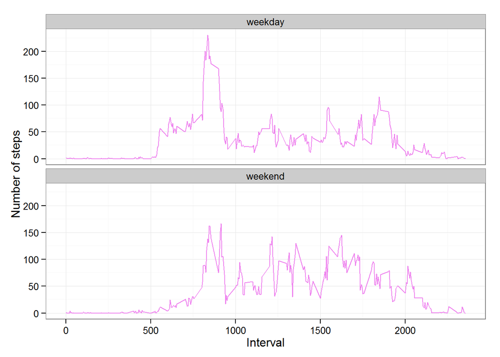

```r
ggplot(data_weekdays, aes(x=interval, y=steps)) +
  geom_line(color="violet") +
  facet_wrap(~ dayofweek, nrow=2, ncol=1) +
  labs(x="Interval", y="Number of steps") +
  theme_bw()
```